# A Data-Driven Study of Loan Approval

Alex Biuckians, Armin Soroosh, Dania Salman, Kaipu Liu

## Abstract

With increasing economic challenges and daily financial demands, the demand for loans continues to rise. Financial institutions receive a large number of loan applications each day, making it difficult to manage them, particularly when evaluations are done manually and there are no reliable methods to assess a candidate’s creditworthiness (Mnkandla et al., 2024). To simplify the process for both applicants and financial institutions, it is essential to develop robust evaluation methods that can accurately predict a loan applicant’s creditworthiness while minimizing risks for lenders. To achieve this, we have decided to explore an existing dataset to identify patterns across various features of loan applicants and determine which factors have the greatest impact on loan approvals. Once these key features are identified, predictive models can be built around them, reducing the need for manual evaluation and enabling data-driven decision-making based on actual application data.

## Introduction

To investigate the factors that influence loan decisions, we obtained a dataset from Kaggle (Sharma, 2023) containing various variables for each loan application, such as income, education, CIBIL score, and the final loan status (Approved or Rejected). Our goal is to examine whether each of these variables has any impact on the loan decision. We have formulated around 10 smart questions that explore the potential effect of each variable on the final outcome. The insights gained from this exploratory analysis will guide the development of predictive models capable of accurately determining whether a loan should be approved for a given applicant.

### Loading the Dataset

```r
# reading dataset
loan_df <- data.frame(read.csv("loan_approval_dataset.csv"))
```

```r
# exploring dataset
str(loan_df)
```

```
## 'data.frame':    4269 obs. of  13 variables:
##  $ loan_id                 : int  1 2 3 4 5 6 7 8 9 10 ...
##  $ no_of_dependents        : int  2 0 3 3 5 0 5 2 0 5 ...
##  $ education               : chr  " Graduate" " Not Graduate" " Graduate" " Graduate" ...
##  $ self_employed           : chr  " No" " Yes" " No" " No" ...
##  $ income_annum            : int  9600000 4100000 9100000 8200000 9800000 4800000 8700000 5700000 800000 1100000 ...
##  $ loan_amount             : int  29900000 12200000 29700000 30700000 24200000 13500000 33000000 15000000 2200000 4300000 ...
##  $ loan_term               : int  12 8 20 8 20 10 4 20 20 10 ...
##  $ cibil_score             : int  778 417 506 467 382 319 678 382 782 388 ...
##  $ residential_assets_value: int  2400000 2700000 7100000 18200000 12400000 6800000 22500000 13200000 1300000 3200000 ...
##  $ commercial_assets_value : int  17600000 2200000 4500000 3300000 8200000 8300000 14800000 5700000 800000 1400000 ...
##  $ luxury_assets_value     : int  22700000 8800000 33300000 23300000 29400000 13700000 29200000 11800000 2800000 3300000 ...
##  $ bank_asset_value        : int  8000000 3300000 12800000 7900000 5000000 5100000 4300000 6000000 600000 1600000 ...
##  $ loan_status             : chr  " Approved" " Rejected" " Rejected" " Rejected" ...
```

The dataset has **4269 observations** with **13 variables**

## Data Cleaning & Summary

### subsetting data and converting categorical variables to factor

Removing `loan_id` column since it only serves as a unique identifier and does not contribute to the analysis. Furthermore, converting several numeric variables into factors, as they represent categorical information rather than continuous numerical values.

```r
loan_df <- subset(loan_df, select = -c(loan_id))

# converting the numeric variables to factor variables
loan_df$no_of_dependents = as.factor(loan_df$no_of_dependents)
loan_df$education = as.factor(loan_df$education)
loan_df$self_employed = as.factor(loan_df$self_employed)
loan_df$loan_status = as.factor(loan_df$loan_status)
str(loan_df)
```

```
## 'data.frame':    4269 obs. of  12 variables:
##  $ no_of_dependents        : Factor w/ 6 levels "0","1","2","3",..: 3 1 4 4 6 1 6 3 1 6 ...
##  $ education               : Factor w/ 2 levels " Graduate"," Not Graduate": 1 2 1 1 2 1 1 1 1 2 ...
##  $ self_employed           : Factor w/ 2 levels " No"," Yes": 1 2 1 1 2 2 1 2 2 1 ...
##  $ income_annum            : int  9600000 4100000 9100000 8200000 9800000 4800000 8700000 5700000 800000 1100000 ...
##  $ loan_amount             : int  29900000 12200000 29700000 30700000 24200000 13500000 33000000 15000000 2200000 4300000 ...
##  $ loan_term               : int  12 8 20 8 20 10 4 20 20 10 ...
##  $ cibil_score             : int  778 417 506 467 382 319 678 382 782 388 ...
##  $ residential_assets_value: int  2400000 2700000 7100000 18200000 12400000 6800000 22500000 13200000 1300000 3200000 ...
##  $ commercial_assets_value : int  17600000 2200000 4500000 3300000 8200000 8300000 14800000 5700000 800000 1400000 ...
##  $ luxury_assets_value     : int  22700000 8800000 33300000 23300000 29400000 13700000 29200000 11800000 2800000 3300000 ...
##  $ bank_asset_value        : int  8000000 3300000 12800000 7900000 5000000 5100000 4300000 6000000 600000 1600000 ...
##  $ loan_status             : Factor w/ 2 levels " Approved"," Rejected": 1 2 2 2 2 2 1 2 1 2 ...
```

After conversion, we have the following variables in the dataset:

#### Variables in dataset

```r
library(knitr)

# Sample data frame
loan_data <- data.frame(
  Variable = c("no_of_dependents", "education", "self_employed", "income_annum", "loan_amount", "loan_term", "cibil_score", "residential_assets_value", "commercial_assets_value", "luxury_assets_value", "bank_asset_value", "loan_status"),
  Description = c("Number of dependents an applicant has ranging from 0 to 5", "Education level (Graduate or Not Graduate)", "Whether the applicant works independently or for an employer", "Annual income of applicant", "Amount of loan requested", "The number of years in which the applicant will repay the loan","Credit score indicating applicants history of repayment", "Value of applicant's residential assets if any", "Value of applicant's commercial assets if any", "Value of applicant's luxury assets if any", "Value of applicant's bank assets if any", "Target variable indicating whether the loan was Approved or Rejected"),
  Type = c("Categorical", "Categorical", "Categorical", "Numeric", "Numeric", "Numeric", "Numeric", "Numeric", "Numeric", "Numeric", "Numeric", "Categorical")
)

# Create table
kable(loan_data)
```

| Variable | Description | Type |
| --- | --- | --- |
| no_of_dependents | Number of dependents an applicant has ranging from 0 to 5 | Categorical |
| education | Education level (Graduate or Not Graduate) | Categorical |
| self_employed | Whether the applicant works independently or for an employer | Categorical |
| income_annum | Annual income of applicant | Numeric |
| loan_amount | Amount of loan requested | Numeric |
| loan_term | The number of years in which the applicant will repay the loan | Numeric |
| cibil_score | Credit score indicating applicants history of repayment | Numeric |
| residential_assets_value | Value of applicant’s residential assets if any | Numeric |
| commercial_assets_value | Value of applicant’s commercial assets if any | Numeric |
| luxury_assets_value | Value of applicant’s luxury assets if any | Numeric |
| bank_asset_value | Value of applicant’s bank assets if any | Numeric |
| loan_status | Target variable indicating whether the loan was Approved or Rejected | Categorical |

### Finding NA values

```r
sum(is.na(loan_df))
```

```
## [1] 0
```

There are no NA values in the data set

### Summary of the dataset

```r
summary(loan_df)
```

```
##  no_of_dependents         education    self_employed  income_annum
##  0:712             Graduate    :2144    No :2119     Min.   : 200000
##  1:697             Not Graduate:2125    Yes:2150     1st Qu.:2700000
##  2:708                                               Median :5100000
##  3:727                                               Mean   :5059124
##  4:752                                               3rd Qu.:7500000
##  5:673                                               Max.   :9900000
##   loan_amount         loan_term     cibil_score  residential_assets_value
##  Min.   :  300000   Min.   : 2.0   Min.   :300   Min.   : -100000
##  1st Qu.: 7700000   1st Qu.: 6.0   1st Qu.:453   1st Qu.: 2200000
##  Median :14500000   Median :10.0   Median :600   Median : 5600000
##  Mean   :15133450   Mean   :10.9   Mean   :600   Mean   : 7472617
##  3rd Qu.:21500000   3rd Qu.:16.0   3rd Qu.:748   3rd Qu.:11300000
##  Max.   :39500000   Max.   :20.0   Max.   :900   Max.   :29100000
##  commercial_assets_value luxury_assets_value bank_asset_value
##  Min.   :       0        Min.   :  300000    Min.   :       0
##  1st Qu.: 1300000        1st Qu.: 7500000    1st Qu.: 2300000
##  Median : 3700000        Median :14600000    Median : 4600000
##  Mean   : 4973155        Mean   :15126306    Mean   : 4976692
##  3rd Qu.: 7600000        3rd Qu.:21700000    3rd Qu.: 7100000
##  Max.   :19400000        Max.   :39200000    Max.   :14700000
##     loan_status
##   Approved:2656
##   Rejected:1613
##
##
##
##
```

### Cleaning up negative values

Checking the number of rows that have negative values for `residential_assets_value` column

```r
sum(loan_df$residential_assets_value < 0)
```

```
## [1] 28
```

There are `28` entries with negative values.

### Removing entries with negative values

```r
loan_df <- loan_df[loan_df$residential_assets_value >= 0, ]
str(loan_df)
```

```
## 'data.frame':    4241 obs. of  12 variables:
##  $ no_of_dependents        : Factor w/ 6 levels "0","1","2","3",..: 3 1 4 4 6 1 6 3 1 6 ...
##  $ education               : Factor w/ 2 levels " Graduate"," Not Graduate": 1 2 1 1 2 1 1 1 1 2 ...
##  $ self_employed           : Factor w/ 2 levels " No"," Yes": 1 2 1 1 2 2 1 2 2 1 ...
##  $ income_annum            : int  9600000 4100000 9100000 8200000 9800000 4800000 8700000 5700000 800000 1100000 ...
##  $ loan_amount             : int  29900000 12200000 29700000 30700000 24200000 13500000 33000000 15000000 2200000 4300000 ...
##  $ loan_term               : int  12 8 20 8 20 10 4 20 20 10 ...
##  $ cibil_score             : int  778 417 506 467 382 319 678 382 782 388 ...
##  $ residential_assets_value: int  2400000 2700000 7100000 18200000 12400000 6800000 22500000 13200000 1300000 3200000 ...
##  $ commercial_assets_value : int  17600000 2200000 4500000 3300000 8200000 8300000 14800000 5700000 800000 1400000 ...
##  $ luxury_assets_value     : int  22700000 8800000 33300000 23300000 29400000 13700000 29200000 11800000 2800000 3300000 ...
##  $ bank_asset_value        : int  8000000 3300000 12800000 7900000 5000000 5100000 4300000 6000000 600000 1600000 ...
##  $ loan_status             : Factor w/ 2 levels " Approved"," Rejected": 1 2 2 2 2 2 1 2 1 2 ...
```

```r
summary(loan_df)
```

```
##  no_of_dependents         education    self_employed  income_annum
##  0:706             Graduate    :2127    No :2106     Min.   : 200000
##  1:696             Not Graduate:2114    Yes:2135     1st Qu.:2700000
##  2:701                                               Median :5100000
##  3:725                                               Mean   :5074251
##  4:744                                               3rd Qu.:7500000
##  5:669                                               Max.   :9900000
##   loan_amount         loan_term     cibil_score  residential_assets_value
##  Min.   :  300000   Min.   : 2.0   Min.   :300   Min.   :       0
##  1st Qu.: 7700000   1st Qu.: 6.0   1st Qu.:453   1st Qu.: 2200000
##  Median :14600000   Median :10.0   Median :600   Median : 5700000
##  Mean   :15178401   Mean   :10.9   Mean   :600   Mean   : 7522613
##  3rd Qu.:21500000   3rd Qu.:16.0   3rd Qu.:747   3rd Qu.:11400000
##  Max.   :39500000   Max.   :20.0   Max.   :900   Max.   :29100000
##  commercial_assets_value luxury_assets_value bank_asset_value
##  Min.   :       0        Min.   :  300000    Min.   :       0
##  1st Qu.: 1300000        1st Qu.: 7500000    1st Qu.: 2400000
##  Median : 3700000        Median :14600000    Median : 4600000
##  Mean   : 4985121        Mean   :15171210    Mean   : 4991488
##  3rd Qu.: 7700000        3rd Qu.:21700000    3rd Qu.: 7100000
##  Max.   :19400000        Max.   :39200000    Max.   :14700000
##     loan_status
##   Approved:2640
##   Rejected:1601
##
##
##
##
```

After filtering out the rows with negative values, the dataset now has `4,241 observations`. The distributions across all variables look almost identical to before, showing that this cleaning step didn’t affect the data overall.

## Exploratory Data Analysis

### Does education level affect loan approval?

Here, we aim to examine whether the person’s **education** (`Graduated` or `Not Graduated`) affects the approval or rejection of a loan. We begin by visualizing the distribution of approved and rejected applications for each education group using a bar chart.

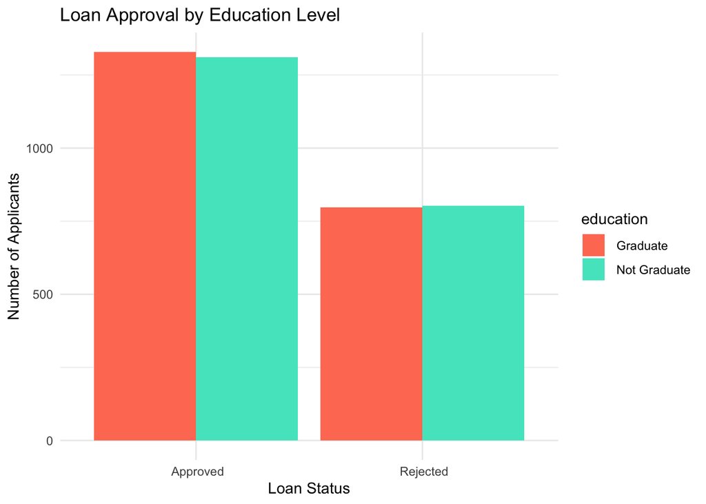

```r
library(ggplot2)
ggplot(loan_df, aes(x = loan_status, fill = education)) +
  geom_bar(position = "dodge") +
  labs(
    title = "Loan Approval by Education Level",
    x = "Loan Status",
    y = "Number of Applicants"
  ) +
  scale_fill_manual(
    values = c(" Graduate" = "#FF7C61", " Not Graduate" = "#50E5C8")
  ) +
  theme_minimal()
```

Approval rates are nearly **identical** for Graduated and Not Graduated applicants, suggesting education likely doesn’t affect loan approval. A Chi-square test will confirm this statistically.

#### Hypotheses:

- **Null hypothesis (H₀):** Loan approval is independent of education level (Graduated vs Not Graduated).
- **Alternative hypothesis (H₁):** Loan approval depends on education level; there is an association between education and loan approval.

```r
edu_table <- table(loan_df$education, loan_df$loan_status)
print(edu_table)
```

```
##
##                  Approved  Rejected
##    Graduate          1329       798
##    Not Graduate      1311       803
```

```r
edu_chi <- chisq.test(edu_table)
print(edu_chi)
```

```
##
##  Pearson's Chi-squared test with Yates' continuity correction
##
## data:  edu_table
## X-squared = 0.08, df = 1, p-value = 0.8
```

#### Conclusion

The Chi-square test yielded a **p-value** of `0.8`. Since this is greater than `0.05`, we fail to reject the null hypothesis, indicating that there is no significant association between education level and loan approval. This confirms that, in this dataset, education does not appear to affect the likelihood of a loan being approved.

### Do people with higher asset values tend to get approved more often?

Here, we aim to examine whether the value of a person’s assets, including residential, commercial, luxury, and bank assets, individually affects the approval or rejection of a loan. We begin by visualizing the frequency distribution of each type of asset value.

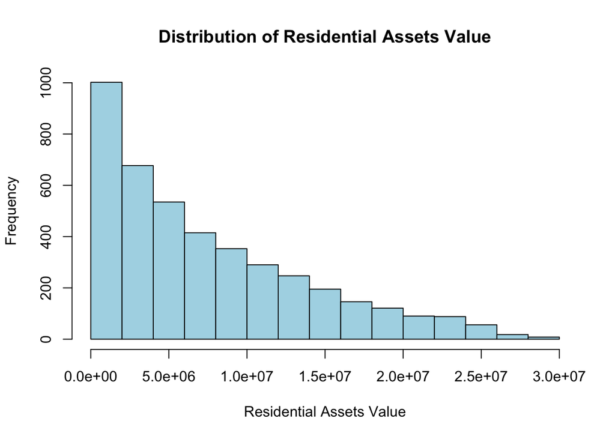

```r
# 1. Residential Assets Histogram
hist(loan_df$residential_assets_value,
     main = "Distribution of Residential Assets Value",
     xlab = "Residential Assets Value",
     col = "lightblue",
     border = "black")
```

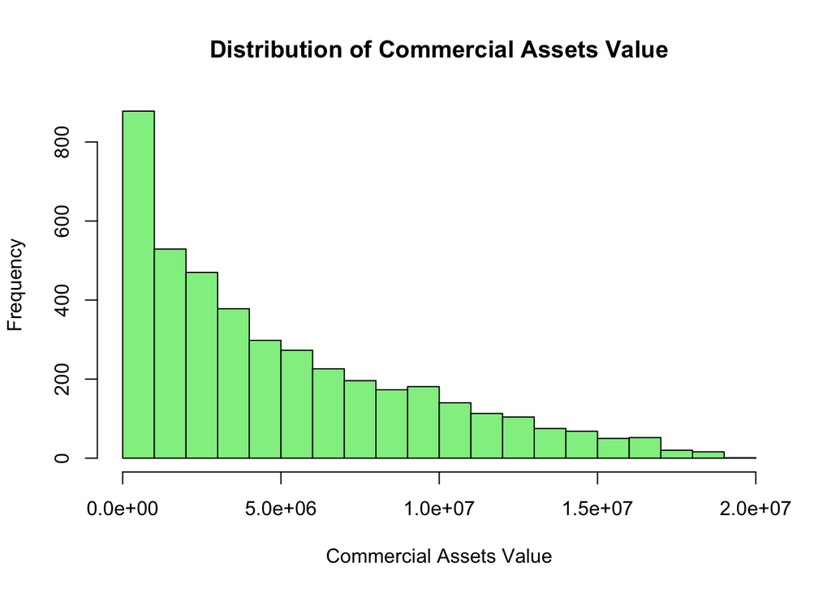

```r
# 2. Commercial Assets Histogram
hist(loan_df$commercial_assets_value,
     main = "Distribution of Commercial Assets Value",
     xlab = "Commercial Assets Value",
     col = "lightgreen",
     border = "black")
```

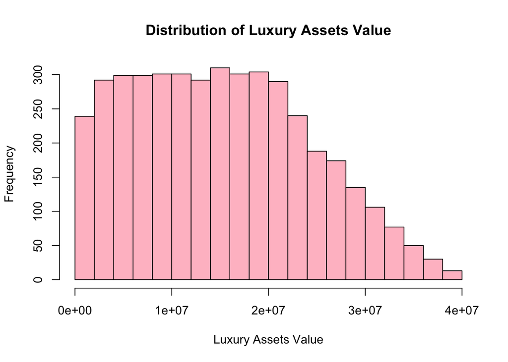

```r
# 3. Luxury Assets Histogram
hist(loan_df$luxury_assets_value,
     main = "Distribution of Luxury Assets Value",
     xlab = "Luxury Assets Value",
     col = "pink",
     border = "black")
```

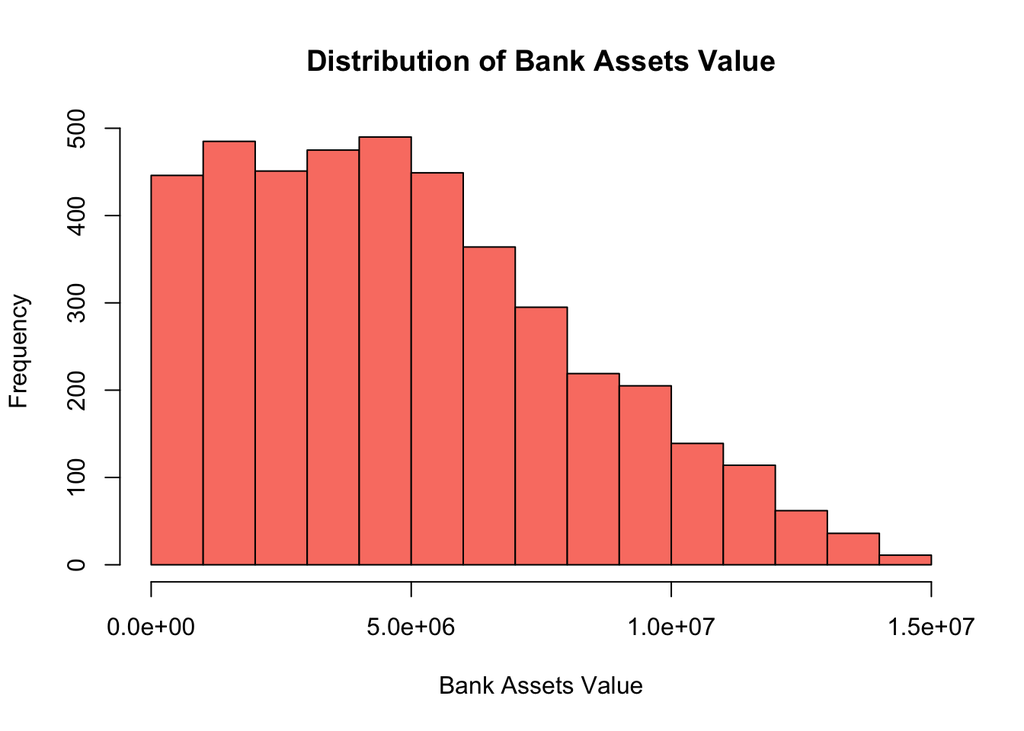

```r
# 4. Bank Assets Histogram
hist(loan_df$bank_asset_value,
     main = "Distribution of Bank Assets Value",
     xlab = "Bank Assets Value",
     col = "salmon",
     border = "black")
```

```r
# Reset plotting layout to default (1 plot per screen) after generation
par(mfrow = c(1, 1))
```

Each type of asset value shows a right-skewed distribution, meaning most individuals hold lower asset values while a smaller number possess much higher ones, indicating non-normality. To statistically verify this, we can apply the Shapiro–Wilk test, which checks whether the data follow a normal distribution.

#### Hypotheses:

- **Null hypothesis (H₀):** The data are normally distributed.
- **Alternative hypothesis (H₁):** The data are not normally distributed. We use this test to confirm whether the visual observation of skewness is statistically significant.

```r
shapiro.test(loan_df$residential_assets_value)
```

```
##
##  Shapiro-Wilk normality test
##
## data:  loan_df$residential_assets_value
## W = 0.9, p-value <2e-16
```

```r
shapiro.test(loan_df$commercial_assets_value)
```

```
##
##  Shapiro-Wilk normality test
##
## data:  loan_df$commercial_assets_value
## W = 0.9, p-value <2e-16
```

```r
shapiro.test(loan_df$luxury_assets_value)
```

```
##
##  Shapiro-Wilk normality test
##
## data:  loan_df$luxury_assets_value
## W = 1, p-value <2e-16
```

```r
shapiro.test(loan_df$bank_asset_value)
```

```
##
##  Shapiro-Wilk normality test
##
## data:  loan_df$bank_asset_value
## W = 1, p-value <2e-16
```

Since all **p-values** are far below `0.05`, we **reject the null hypothesis** for each test. This indicates that none of the asset value distributions are normally distributed, which is consistent with the right-skewed patterns observed in the histograms. Let’s visualize the impact of asset values on loan status using a **box plot**.

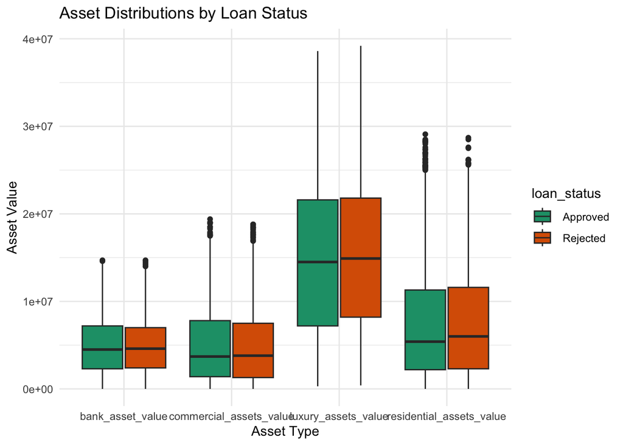

```r
# Convert to long format
loan_long <- loan_df %>%
  pivot_longer(
    cols = c(residential_assets_value, commercial_assets_value, luxury_assets_value, bank_asset_value),
    names_to = "asset_type",
    values_to = "asset_value"
  )

# Boxplots all in one figure
ggplot(loan_long, aes(x = asset_type, y = asset_value, fill = loan_status)) +
  geom_boxplot(position = position_dodge(width = 0.8)) +
  labs(
    title = "Asset Distributions by Loan Status",
    x = "Asset Type",
    y = "Asset Value"
  ) +
  theme_minimal() +
  scale_fill_manual(values = c(" Approved" = "#1b9e77", " Rejected" = "#d95f02"))
```

The **median** and **range** of each asset type are similar between `Approved` and `Rejected` loans, suggesting little apparent effect on loan decisions. Since the Shapiro-Wilk test showed that asset values are not normally distributed, we use the Wilcoxon rank-sum test to formally assess differences.

#### Hypotheses for each asset type:

- **Null hypothesis (H₀):** The distribution of asset values is the same for Approved and Rejected loans.
- **Alternative hypothesis (H₁):** The distribution of asset values differs between Approved and Rejected loans.

```r
wilcox.test(residential_assets_value ~ loan_status, data = loan_df)
```

```
##
##  Wilcoxon rank sum test with continuity correction
##
## data:  residential_assets_value by loan_status
## W = 2e+06, p-value = 0.2
## alternative hypothesis: true location shift is not equal to 0
```

```r
wilcox.test(commercial_assets_value ~ loan_status, data = loan_df)
```

```
##
##  Wilcoxon rank sum test with continuity correction
##
## data:  commercial_assets_value by loan_status
## W = 2e+06, p-value = 0.7
## alternative hypothesis: true location shift is not equal to 0
```

```r
wilcox.test(luxury_assets_value ~ loan_status, data = loan_df)
```

```
##
##  Wilcoxon rank sum test with continuity correction
##
## data:  luxury_assets_value by loan_status
## W = 2e+06, p-value = 0.2
## alternative hypothesis: true location shift is not equal to 0
```

```r
wilcox.test(bank_asset_value ~ loan_status, data = loan_df)
```

```
##
##  Wilcoxon rank sum test with continuity correction
##
## data:  bank_asset_value by loan_status
## W = 2e+06, p-value = 0.4
## alternative hypothesis: true location shift is not equal to 0
```

#### Conclusion

All **p-values** are greater than `0.05`, so we **fail to reject the null hypothesis** for each asset type. This indicates that there is no statistically significant difference in asset values between Approved and Rejected loans, supporting the initial observation that **asset values do not appear to affect loan approval decisions**.

### Is there a significant difference in average income between approved and rejected applicants?

Here, we aim to examine whether the person’s **annual income** affects the approval or rejection of a loan. We begin by visualizing the frequency distribution of annual income.

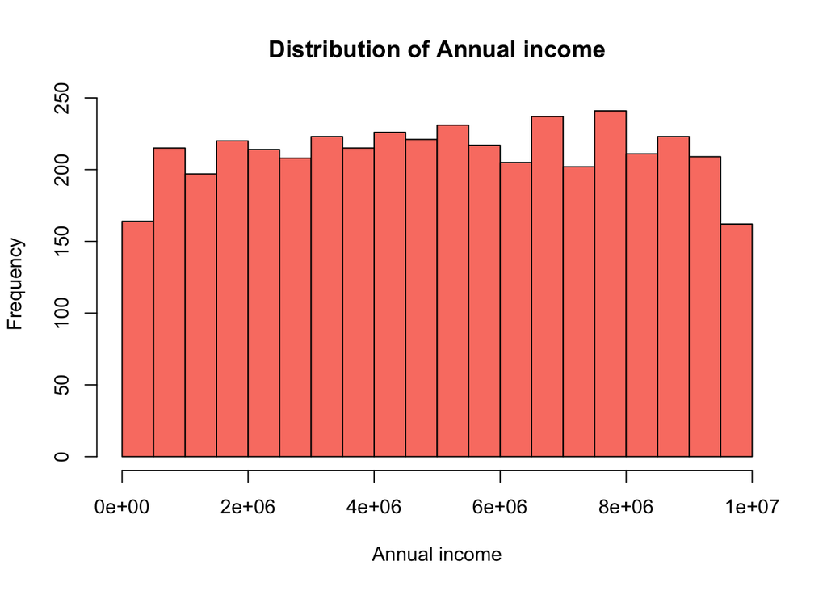

```r
hist(loan_df$income_annum,
     main = "Distribution of Annual income",
     xlab = "Annual income",
     col = "salmon",
     border = "black")
```

The frequency distribution shows that annual income is **roughly uniform and symmetric**, with **no noticeable skew or extreme outliers**. We can now examine the distribution of annual income for `Approved` and `Rejected` applicants using a box plot.

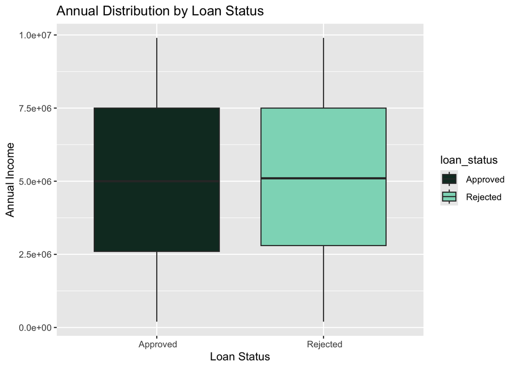

```r
ggplot(loan_df, aes(x = loan_status, y = income_annum, fill = loan_status)) +
  geom_boxplot() +
  labs(title = "Annual Distribution by Loan Status", x = "Loan Status", y = "Annual Income") +
  scale_fill_manual(values = c(" Approved" = "#12362A", " Rejected" = "#8DD9C1"))
```

The box plot shows that the income distributions for both `Approved` and `Rejected` applicants are quite similar. The **median** income for both groups is approximately `5 million`, and the small difference in the lower quartiles appears negligible. To statistically verify this observation, we will perform a two-sample t-test to compare the means of the two groups.

- **Null Hypothesis (H₀):** There is no significant difference in the average annual income between approved and rejected applicants.
- **Alternative Hypothesis (H₁):** There is a significant difference in the average annual income between approved and rejected applicants.

```r
approved_income <- loan_df$income_annum[loan_df$loan_status == " Approved"]
rejected_income <- loan_df$income_annum[loan_df$loan_status == " Rejected"]
t.test(approved_income, rejected_income)
```

```
##
##  Welch Two Sample t-test
##
## data:  approved_income and rejected_income
## t = -1, df = 3435, p-value = 0.2
## alternative hypothesis: true difference in means is not equal to 0
## 95 percent confidence interval:
##  -277421   68867
## sample estimates:
## mean of x mean of y
##   5034886   5139163
```

#### Conclusion

Since the `p-value(0.2)> 0.05`, we **fail to reject the null hypothesis**, indicating that there is no statistically significant difference in mean income between Approved and Rejected applicants.So the data supports the earlier observation from the box plot i.e. annual income does not appear to affect loan approval in this dataset.

### Is there a correlation between applicant’s annual income and loan amount requested?

Here, we aim to examine whether the **loan amount requested** is influenced by an applicant’s **annual income**. Understanding this relationship helps identify potential **multicollinearity**. Moreover, We already know that annual income is not skewed and roughly uniform and symmetric, we can now visualize the distribution for loan amount requested.

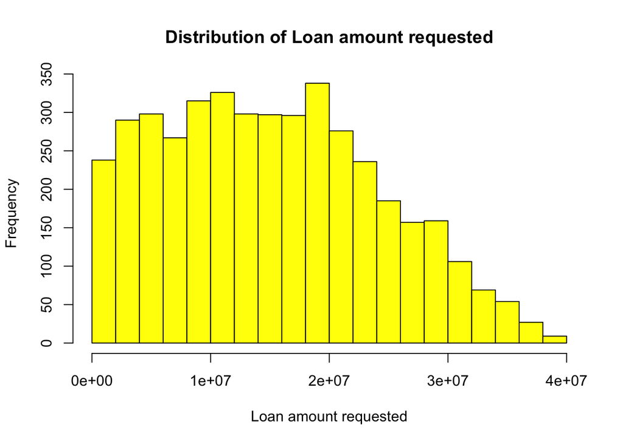

```r
hist(loan_df$loan_amount,
     main = "Distribution of Loan amount requested",
     xlab = "Loan amount requested",
     col = "yellow",
     border = "black")
```

The distribution of loan amount is right-skewed and deviates from normality. Therefore, we will first visualize the relationship between annual income and the requested loan amount, and then use Spearman’s correlation test, as it does not assume normality.

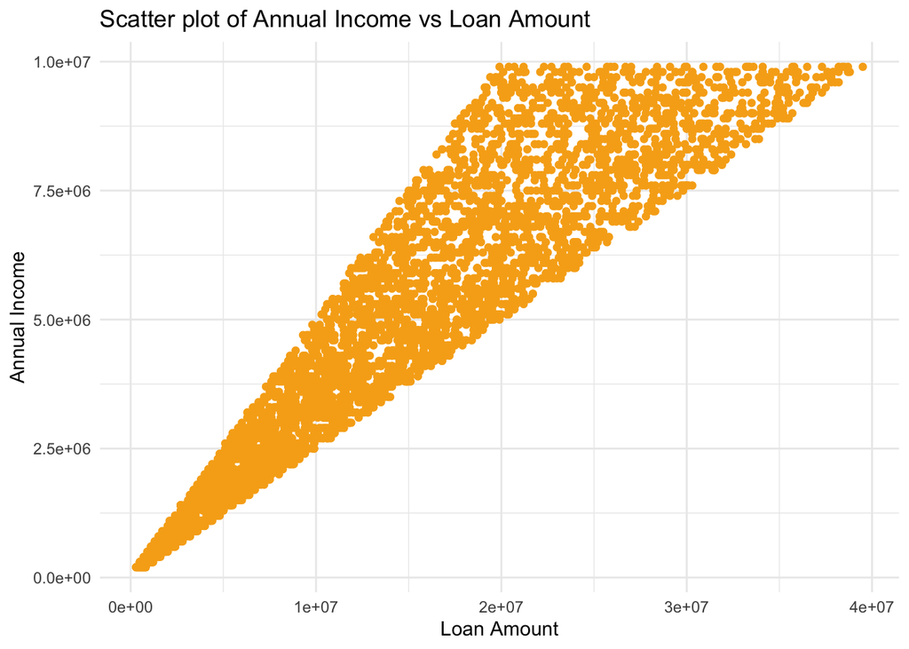

```r
annual_income <- loan_df$income_annum
loan_amount <- loan_df$loan_amount

ggplot(data = loan_df, aes(x = loan_amount, y = income_annum)) +
  geom_point(color = "#F7AC19") +
  labs(
    title = "Scatter plot of Annual Income vs Loan Amount",
    x = "Loan Amount",
    y = "Annual Income"
  ) +
  theme_minimal()
```

A positive correlation is evident, indicating that applicants with higher annual incomes tend to apply for and receive larger loan amounts. We can use a spearman correlation test to verify this.

- **Null Hypothesis (H₀):** There is no relationship between annual income and loan amount among applicants.
- **Alternative Hypothesis (H₁):** Applicants with higher annual incomes tend to apply for and receive larger loan amounts.

```r
cor.test(annual_income, loan_amount, method = "spearman")
```

```
##
##  Spearman's rank correlation rho
##
## data:  annual_income and loan_amount
## S = 8e+08, p-value <2e-16
## alternative hypothesis: true rho is not equal to 0
## sample estimates:
##   rho
## 0.941
```

#### Conclusion:

The Spearman’s rank correlation test shows a very strong positive correlation between annual income and loan amount `(ρ = 0.941, p < 0.001)`. This indicates that as applicants’ annual income increases, the loan amount they apply for and receive also tends to increase. Since the p-value is far below `0.05`, we reject the null hypothesis and conclude that there is a significant positive relationship between annual income and loan amount. This strong association suggests that the two variables convey similar information.

### Is there a significant difference in average CIBIL scores between approved and rejected applicants?

Here, we are investigating to see if there is a significant difference in CIBIL Scores of Approved and Rejected candidates. First we plot the entire distribution to identify outliers then we plot a chart showing the Approved and Rejected populations.

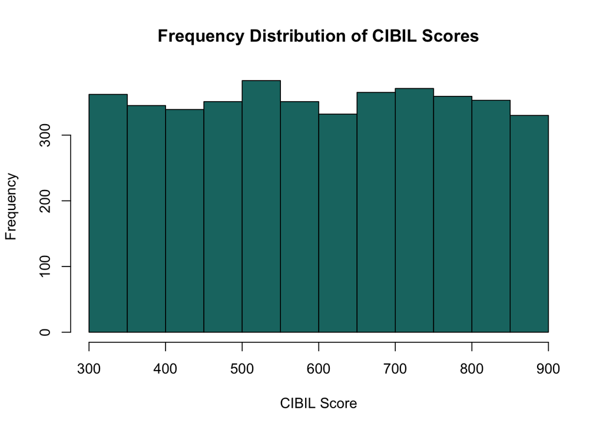

```r
library(ggplot2)
#CIBIL score frequency distribution
hist(loan_df$cibil_score, main = "Frequency Distribution of CIBIL Scores", xlab = "CIBIL Score", ylab = "Frequency", breaks = 15, col = "#197571")
```

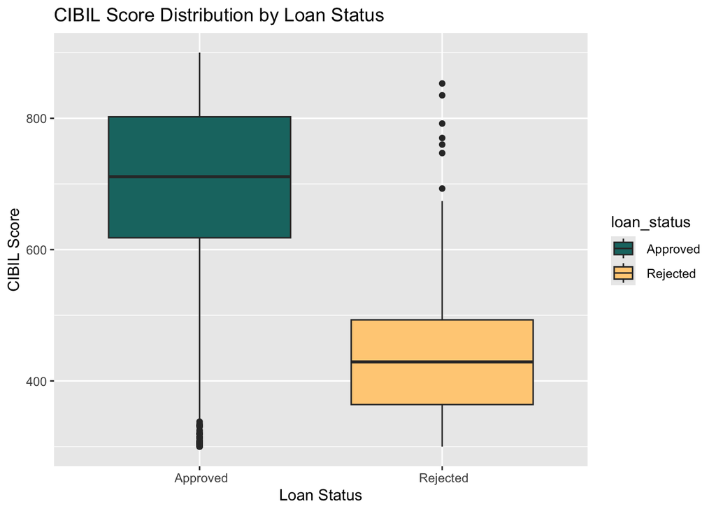

```r
#CIBIL score frequency box chart
ggplot(loan_df, aes(x = loan_status, y = cibil_score, fill = loan_status)) +
  geom_boxplot() +
  labs(title = "CIBIL Score Distribution by Loan Status", x = "Loan Status", y = "CIBIL Score") +
  scale_fill_manual(values = c(" Approved" = "#197571", " Rejected" = "#FFCF85"))
```

```r
#t-test
t.test(cibil_score ~ loan_status, data = loan_df)
```

```
##
##  Welch Two Sample t-test
##
## data:  cibil_score by loan_status
## t = 88, df = 4238, p-value <2e-16
## alternative hypothesis: true difference in means between group  Approved and group  Rejected is not equal to 0
## 95 percent confidence interval:
##  268 280
## sample estimates:
## mean in group  Approved mean in group  Rejected
##                     703                     429
```

#### Hypotheses:

- **Null hypothesis (H₀):** The average CIBIL Scores for Approved and Rejected applicants are equal.
- **Alternative hypothesis (H₁):** The average CIBIL Scores for Approved and Rejected applicants are not equal.

We use this test to confirm whether the CIBIL Scores for the Approved and Rejected applicants are statistically significantly different or the same.

#### Conclusion

The overall CIBIL score frequency distribution shows no apparent outliers. The individual distributions for approved and rejected loans show a few outliers, but it is not necessary to remove them. Even though the outliers are dragging the two means closer to each other, the means are still significantly different even when including them in the t-test.

There is a significant difference in CIBIL scores between approved and rejected applicants because the p-value, `2e-16`, is much lower than the standard alpha threshold of `0.05`. This allows us to reject the null hypothesis that the two means of approved and rejected applicants are **equal**.

### For rejected loans, is there a significant difference in the mean CIBIL score between applicants with shorter loan term loans (<=10 years) versus longer term loans(>10 years)?

Here, we are investigating to see if there is a significant difference in CIBIL Scores in the Rejected applicant population depending if they want a short (less than or equal to 10 years) vs longer term loan (greater than 10 years). First we plot the entire distribution to identify outliers then we plot a chart showing the Rejected population with shorter and longer term loans.

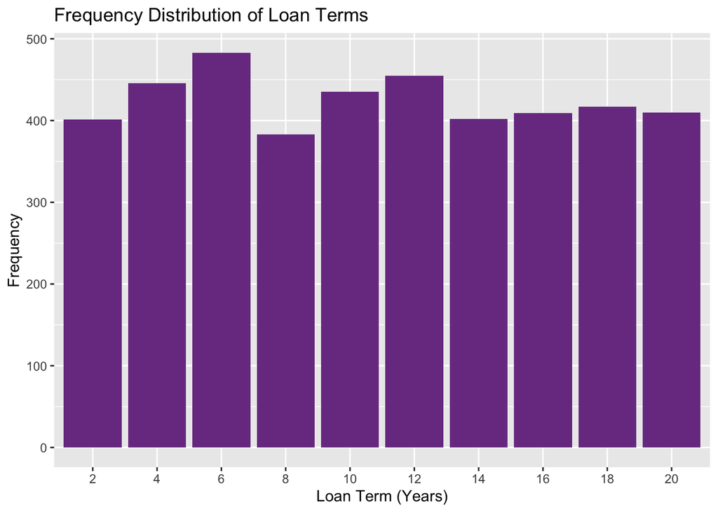

```r
#created subsets for shorter and longer loans then ran t-test
rejected_shorter <- subset(loan_df, trimws(loan_status) == "Rejected" & loan_term <= 10)
rejected_longer <- subset(loan_df, trimws(loan_status) == "Rejected" & loan_term > 10)

#Overall loan term frequency distribution
ggplot(loan_df, aes(x = factor(loan_term))) + geom_bar(fill = "#7B3D91") + labs(title = "Frequency Distribution of Loan Terms", x = "Loan Term (Years)", y = "Frequency")
```

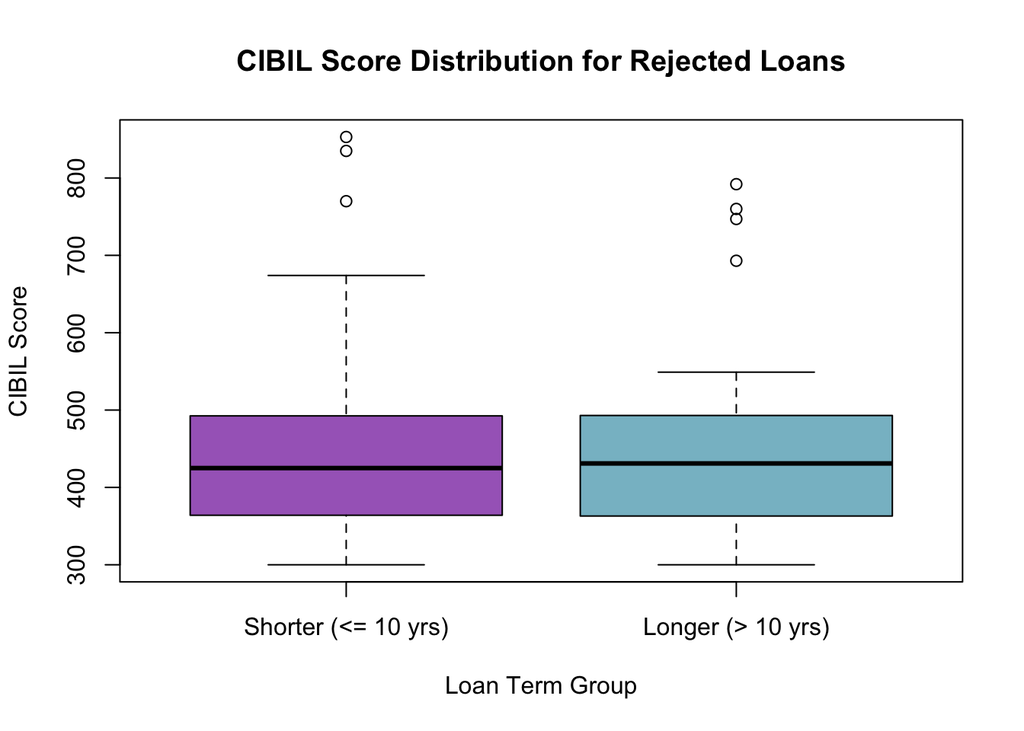

```r
#boxplot
boxplot(
  rejected_shorter$cibil_score,
  rejected_longer$cibil_score,
  names = c("Shorter (<= 10 yrs)", "Longer (> 10 yrs)"),
  main = "CIBIL Score Distribution for Rejected Loans",
  ylab = "CIBIL Score",
  xlab = "Loan Term Group",
  col = c("#A769C2", "#87BDCC")  # add your custom colors here
)
```

```r
#removing outliers
removeOutliers <- function(x) {Q1 <- quantile(x, 0.25)
Q3 <- quantile(x, 0.75);
IQR_val <- Q3 - Q1;
lower_bound <- Q1 - (1.5 * IQR_val);
upper_bound <- Q3 + (1.5 * IQR_val);

return(x[x >= lower_bound & x <= upper_bound]);}

cleaned_shorter_cibil <- removeOutliers(rejected_shorter$cibil_score)
cleaned_longer_cibil <- removeOutliers(rejected_longer$cibil_score)

t.test(rejected_shorter$cibil_score, rejected_longer$cibil_score)
```

```
##
##  Welch Two Sample t-test
##
## data:  rejected_shorter$cibil_score and rejected_longer$cibil_score
## t = -0.03, df = 1564, p-value = 1
## alternative hypothesis: true difference in means is not equal to 0
## 95 percent confidence interval:
##  -7.72  7.51
## sample estimates:
## mean of x mean of y
##       429       429
```

```r
t.test(cleaned_shorter_cibil, cleaned_longer_cibil)
```

```
##
##  Welch Two Sample t-test
##
## data:  cleaned_shorter_cibil and cleaned_longer_cibil
## t = -0.05, df = 1563, p-value = 1
## alternative hypothesis: true difference in means is not equal to 0
## 95 percent confidence interval:
##  -7.47  7.09
## sample estimates:
## mean of x mean of y
##       427       428
```

#### Hypothesis:

- **Null hypothesis (H₀):** The average CIBIL Scores of Rejected applicants with shorter loan terms (less than or equal to 10 years) is equal to that of Rejected applicants with longer loan term (greater than 10 years).
- **Alternative hypothesis (H₁):** The average CIBIL Scores of Rejected applicants with shorter loan terms (less than or equal to 10 years) is not equal to that of Rejected applicants with longer loan term (greater than 10 years).

We use this test to confirm whether the CIBIL Scores for the Rejected applicants with shorter loan terms and longer loan terms are statistically significantly different or the same.

#### Conclusion

The overall loan terms frequency distribution shows no apparent outliers however there are a few in the shorter and longer loan term groups. Having this said, even when removing these outliers there no significant differences found between the two groups and their respective CIBIL scores.

There is not a significant difference in CIBIL scores between shorter `(<= 10 years)` and longer `(>10 years)` term loans within the rejected group of applicants because the **p-value**, `1`, is much higher than the standard alpha threshold of `0.05`. This allows us to accept the null hypothesis that the two means of shorter and longer term loans of rejected applicants are equal.

### Is there a correlation between the CIBIL Score and the Loan Term among those whose loans are approved?

Here, we are investigating whether or not there is a correlation among Approved applicants between the two variables, CIBIL Score and Loan Term (Years). A correlation test is conducted to determine the correlation coefficient and p-value. A graph is also plotted showing the relationship between CIBIL Score and Loan Term.

```r
#correlation coefficient
corr_r <- cor(loan_df[trimws(loan_df$loan_status) == "Approved", "cibil_score"], loan_df[trimws(loan_df$loan_status) == "Approved", "loan_term"], method = "pearson")

#correlation test
cor.test(loan_df[trimws(loan_df$loan_status) == "Approved", "cibil_score"], loan_df[trimws(loan_df$loan_status) == "Approved", "loan_term"], method = "pearson")
```

```
##
##  Pearson's product-moment correlation
##
## data:  loan_df[trimws(loan_df$loan_status) == "Approved", "cibil_score"] and loan_df[trimws(loan_df$loan_status) == "Approved", "loan_term"]
## t = 11, df = 2638, p-value <2e-16
## alternative hypothesis: true correlation is not equal to 0
## 95 percent confidence interval:
##  0.173 0.246
## sample estimates:
##  cor
## 0.21
```

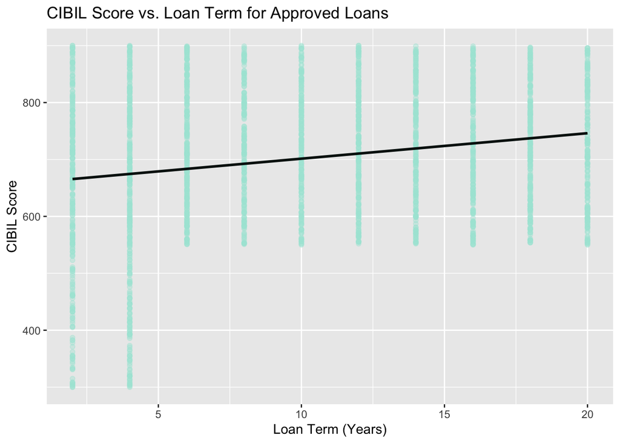

```r
#scatter plot
ggplot(subset(loan_df, trimws(loan_status) == "Approved"), aes(x = loan_term, y = cibil_score)) + geom_point(alpha = 0.4, color = "#AAE5D8") + geom_smooth(method = "lm", se = FALSE, color = "#061411") + labs(title = "CIBIL Score vs. Loan Term for Approved Loans", x = "Loan Term (Years)", y = "CIBIL Score")
```

#### Hypothesis:

- **Null hypothesis (H₀):** There is no correlation between CIBIL Score and Loan Term (Years) of Approved applicants.
- **Alternative hypothesis (H₁):** There is a correlation between CIBIL Score and Loan Term (Years) of Approved applicants.

We use this test to confirm whether there is a correlation between CIBIL Scores and loan terms for the applicants who were Approved for their loan.

#### Conclusion

The correlation coefficient of `0.21` shows a weak but positive relationship where approved candidates with higher CIBIL scores have a slightly higher tendency to approved for longer loan terms. And the p-value is very small, `2e-16`, meaning that the correlation coefficient is unlikely due to chance.

### Does self-employment status affect loan approval?

Here, we aim to examine whether the person’s employment status affects the approval or rejection of a loan. We begin by visualizing the distribution of approved and rejected applications for each employment group using a bar chart.

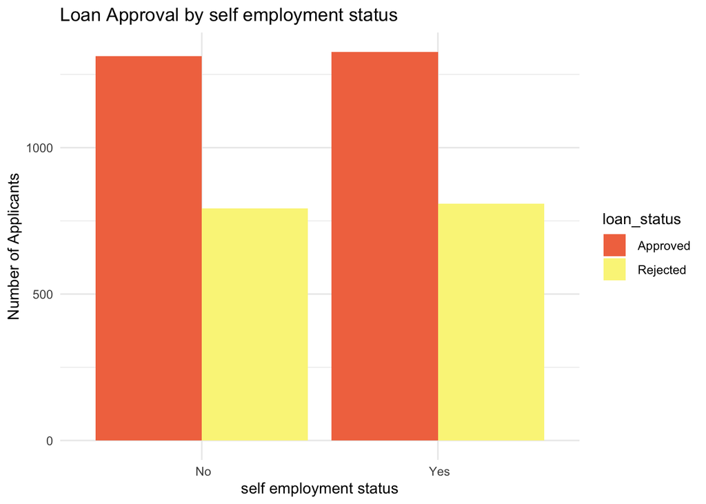

```r
ggplot(loan_df, aes(x = self_employed, fill = loan_status)) +
  geom_bar(position = "dodge") +
  labs(
    title = "Loan Approval by self employment status",
    x = "self employment status",
    y = "Number of Applicants"
  ) +
  scale_fill_manual(values = c(" Approved" = "#F2764E", " Rejected" = "#FAF487")) +
  theme_minimal()
```

Approval rates are nearly **identical** for self-employed and non self-employed applicants, suggesting self-employment likely doesn’t affect loan approval. A Chi-square test will confirm this statistically.

#### Hypotheses:

- **Null hypothesis (H₀):** Loan approval is independent of employment status
- **Alternative hypothesis (H₁):** Loan approval depends on employment status; there is an association between employment status and loan approval.

```r
contable <- table(loan_df$self_employed, loan_df$loan_status)
chisq.test(contable)
```

```
##
##  Pearson's Chi-squared test with Yates' continuity correction
##
## data:  contable
## X-squared = 0.009, df = 1, p-value = 0.9
```

### Does the number of dependents affect approval of loans?

Here, we will see whether the person’s dependents affects the approval or rejection of a loan. We begin by visualizing the distribution of approved and rejected applications for each dependents’ group using a bar chart.

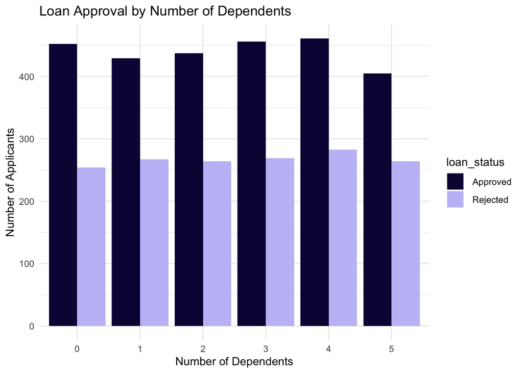

```r
ggplot(loan_df, aes(x = no_of_dependents, fill = loan_status)) +
  geom_bar(position = "dodge") +
  labs(
    title = "Loan Approval by Number of Dependents",
    x = "Number of Dependents",
    y = "Number of Applicants"
  ) +
  scale_fill_manual(values = c(" Approved" = "#0D0942", " Rejected" = "#C4C0F6")) +
  theme_minimal()
```

The bar chart shows that approval and rejection counts are fairly similar across all dependent categories, with no noticeable trend suggesting that the number of dependents strongly influences loan approval outcomes. While minor variations exist, the approval rate appears consistent across groups, indicating that loan approval is likely independent of the number of dependents. A Chi-square test will confirm this statistically.